# Crithidia Field Flower Data exploration V1_2

Sonja

1/31/2022

This is my SECOND attempt at data exploration for the Crithidia presence/absence and LOG10(crith infection counts) vs. farms, visit and field flower abundance.

I will use the data exploring techniques from the ECO 636 class. I also added Julian date column and a column that specifies log10(sunflower, nonsfcut, border).

I have some issue with how we collected sunflower data. Namely, in SIMP we only quantified the sunflower planting during the first visit. I think it was there for at least the second visit as well.

I am using the “crit_ast_v1.csv”.

Here are values for the different variables in the “crit_ast_v1.csv” dataframe

#### random factors (probably)

- “farm” = farm
- “bee_ID” = bee_ID

#### response / dependent variables

- “PA” = presence/absent crithidia
- “crit_cnt” = raw crith count
- “log10_cnt” = log10 crith count

#### independent / explanatory

- “sf” = log10(sum all sunflower flr inflr)
- “nsfcut” = log10(sum all non sunflower cut flr inflr)
- “border” = log10(sum all border flr inflr)
- “cut” = log10(sum all cut flr inflr)
- “log.sum_ast_inflr” = log10(sum all asteraceae flr inflr)

#### covariates / other explanatory variables

- “sp” = bombus sp.
- “Wing_MM” = wing size
- “j_date” = julian date
- “visit” = visit

I chose these variables because this is what Rosemary used in her sunflower data set. All data has been log10 transformed.

The flowers in the field are divided into log10(total abundance of flower head or inflorescence) for cut (includes sunflowers), sunflower, non sunflower cut, border, and total Asteraceae flowers.

The general hypothesis is that cut flowers from the asteraceae family have a negative effect on Crithidia infection in bumble bees. We predict that cut flower abundance will be negatively related to crithidia infection, both presence and infection intensity.

We are secondarily interested in how all the asteraceae flowers including wild border flowers abundances are related to crithidia infection. This is problematic because we did not measure these abundances as consistently across farms across all visits.

Because of the known effect of sunflower pollen on crithidia infection we also have created variables with just sunflower separated from cut flowers.

We are also interested in looking at the covariates wing_mm ( for size of bee ), Julian date (for how infection levels changes over the season), we may also be interested in the number of site visit which could be realted to peak flowering at a certain farm.

## General Bombus species exploration

### Bombus sp. abundance, between farm and visits.

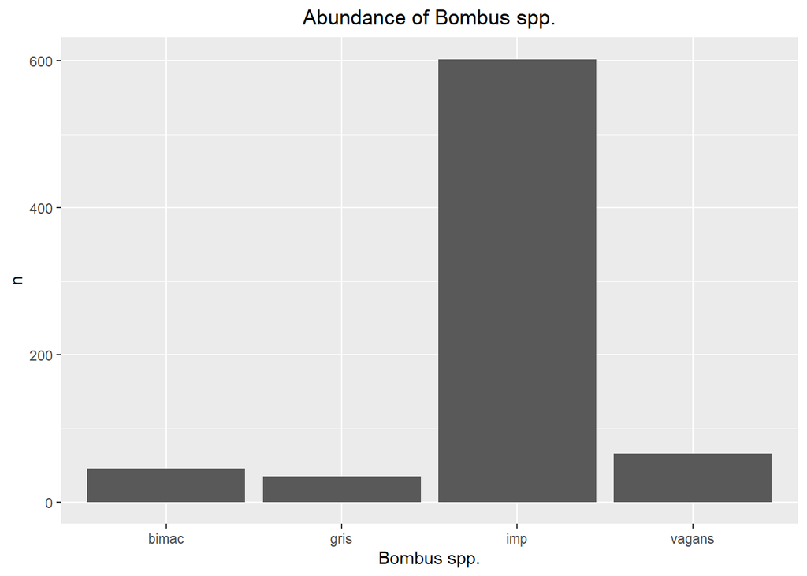

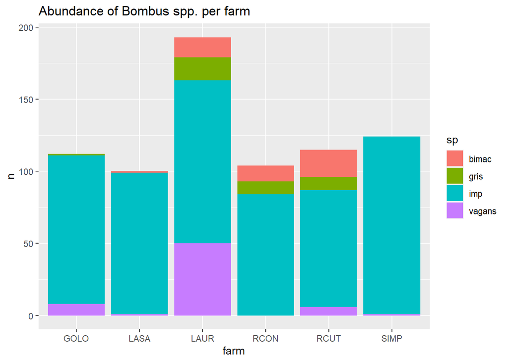

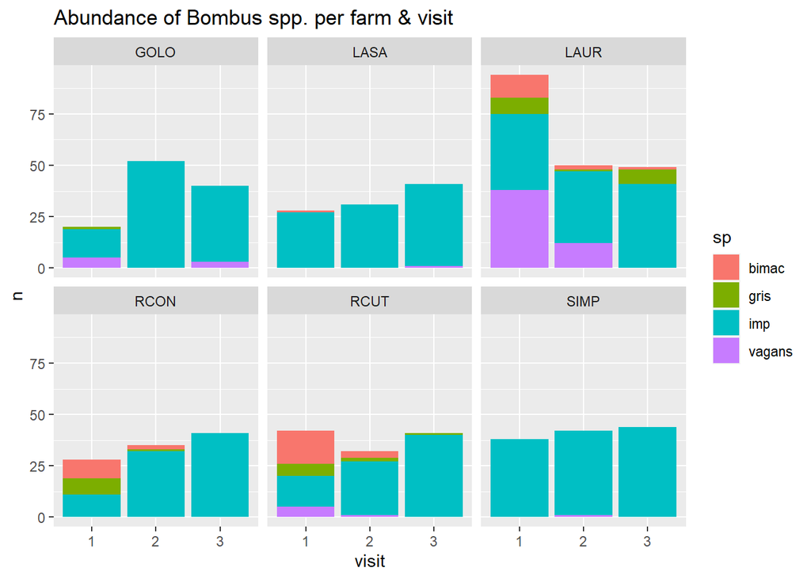

We can see that it is challenging to compare between farm, visit and species because of the low number of non-imp species collected.

We could perform various models one where we group across imp and non-imp. Depending on how we want treat the visit category as a replicate or not, we could combine all visits and farms and perform a model that would just look at imp vs non-imp on the levels of flower abundance. The replicates would be 6 for farms and not all farms would have an observation of each species, but at least 1 non-imp…

Lynn does not like grouping based on non-imp

### Bombus sp and presence vs. absent Crithdia infection

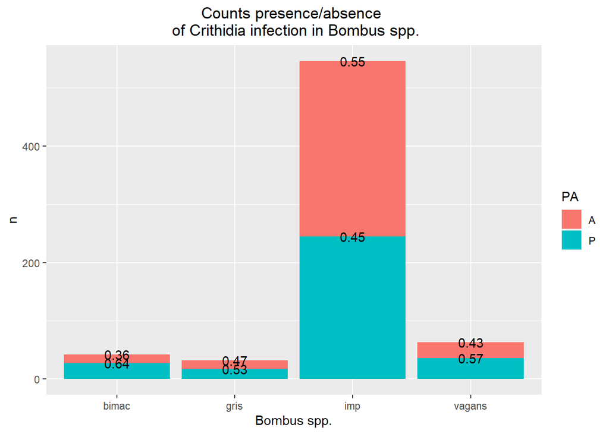

Impatiens has the highest value of crithidia infection absence relative to presence, bimac has the least. Out all of the species, relative to the total amount of bees collected, the bees with the most infection presence was bimac > vagans > gris > imp.

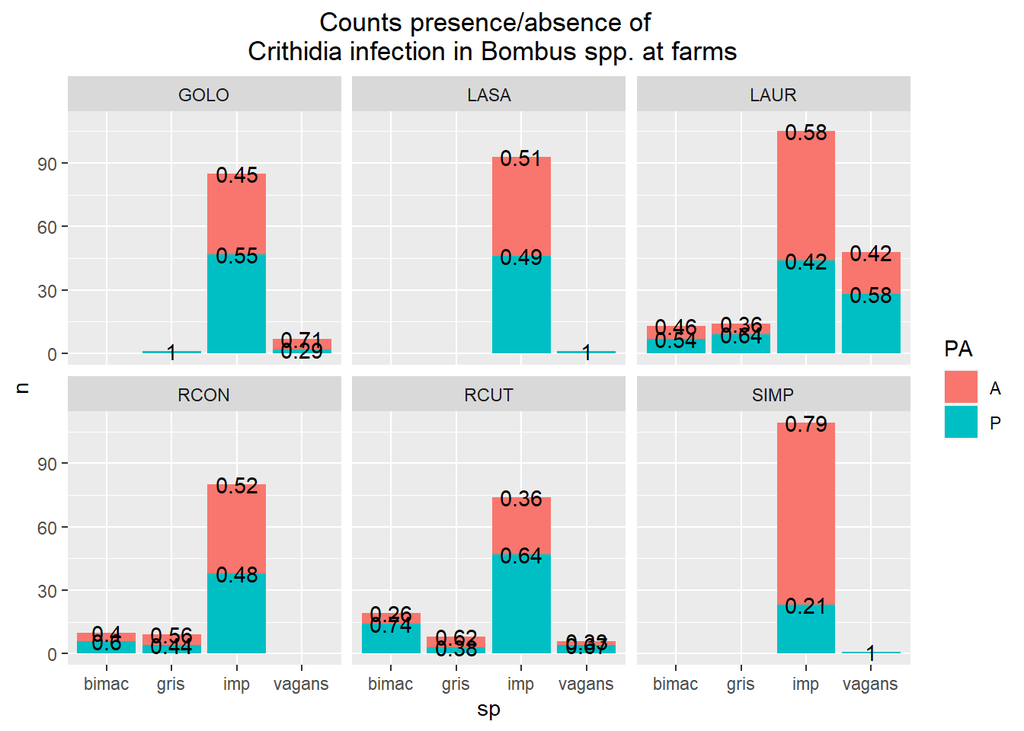

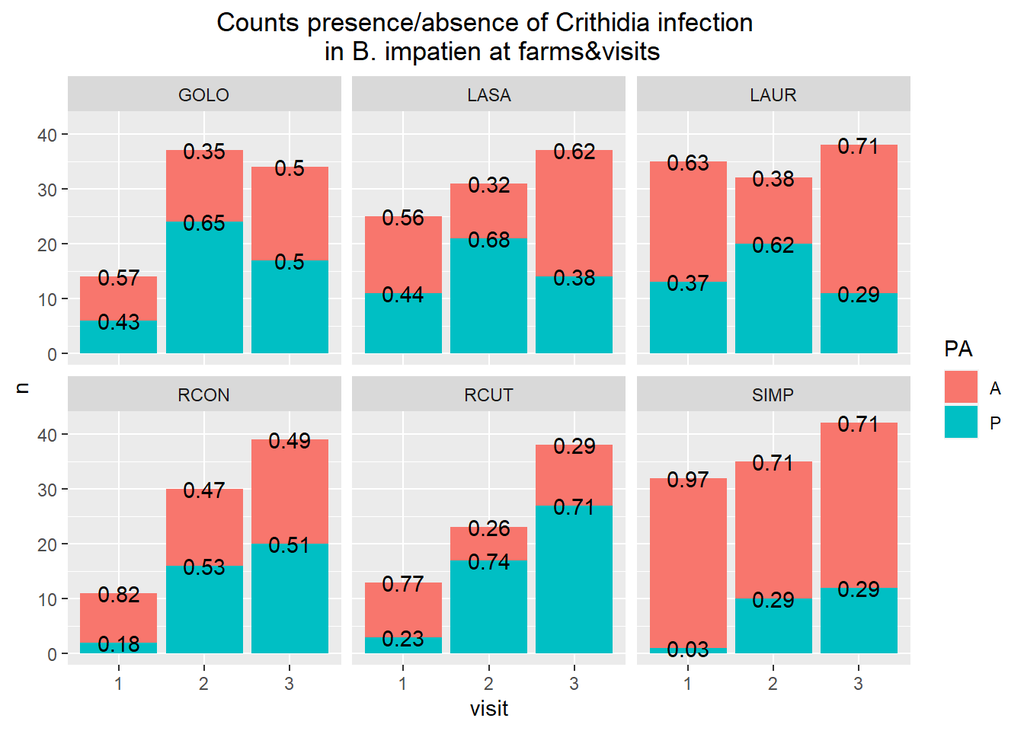

How weird!!!! It looks like for some farms there is in increase of presence of crith infection over time, except in the farms GOLO, LASA and LAUR… this is strange… I can almost make an guess that it could be due to an increase in asteraceae floral resources… I am not sure how to add error bars on this graph.

### Bombus sp and average log10(Crithidia counts)

This data is only using bees that had an observed infection. So the bees with “P” in the PA category.

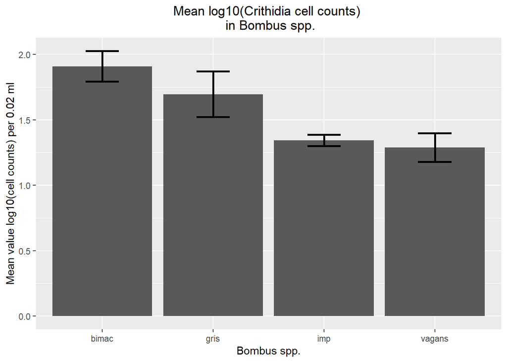

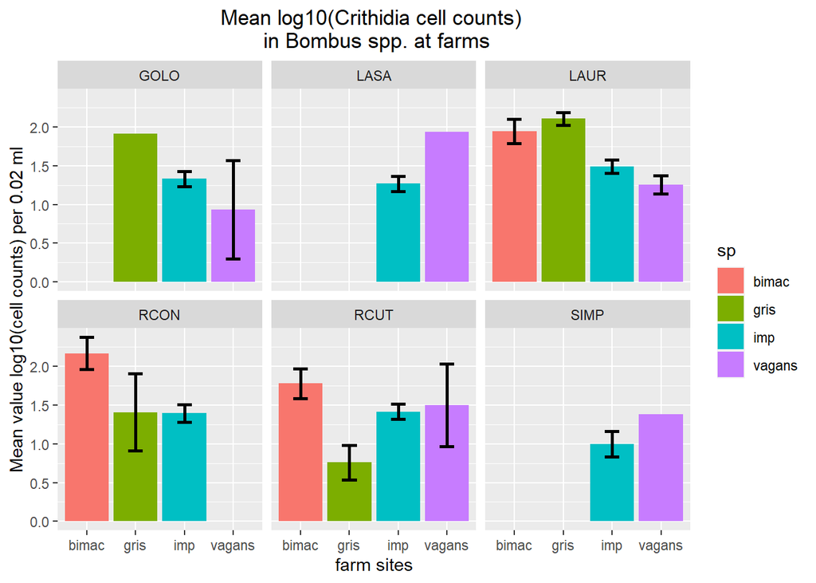

Perhaps if we did a comparison w/in bombus species only in the sites that they were present, perhaps we could see a slight effect of amount of asteraceae flowers.

The bars w/o error bars are instances where there was only 1 observation of a specific species at a specific site.

I will look at how the cnts of Crithidia cell may vary across visits and farms in impatiens. I do not this it is possible to look at this for the other species due to low numbers…

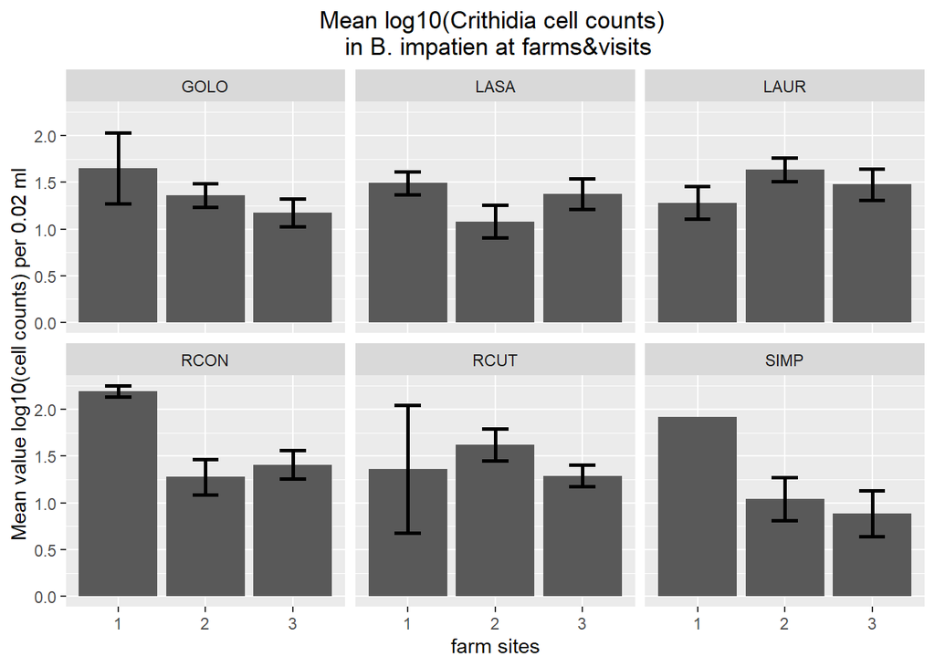

There might be a slight trend between time and crith cell counts.

I think it would be more informative to look at total counts by floral abundances rather than site visits before anything else.

###start here Flower abundances across sites

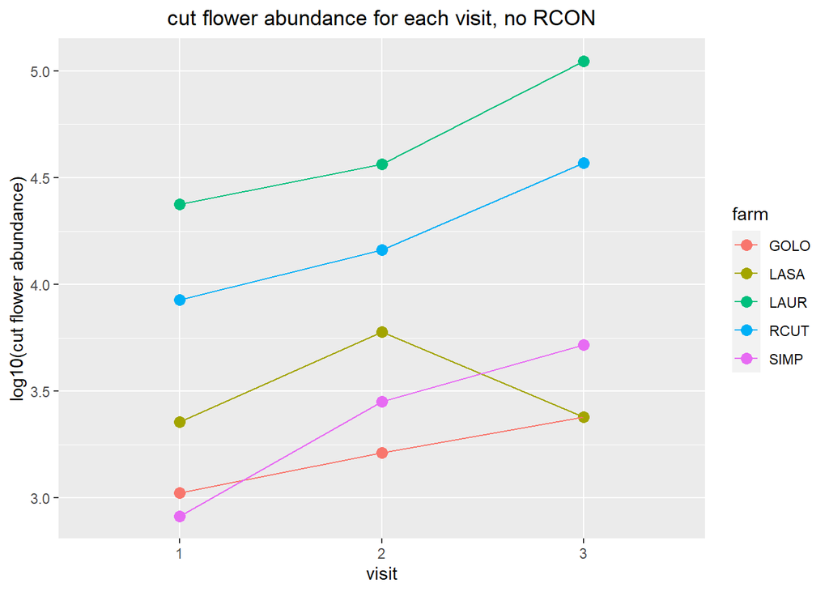

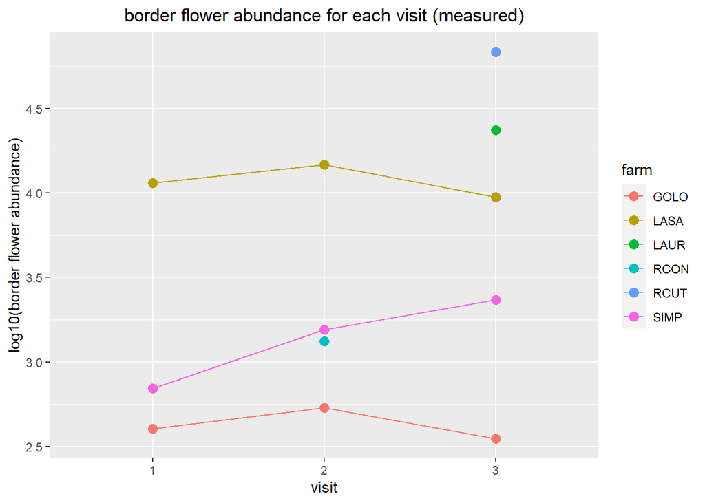

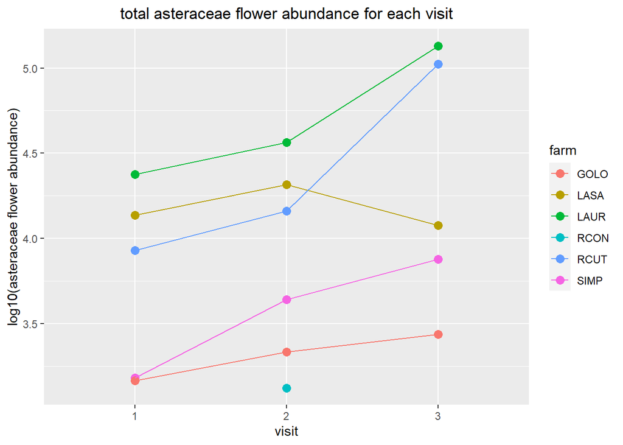

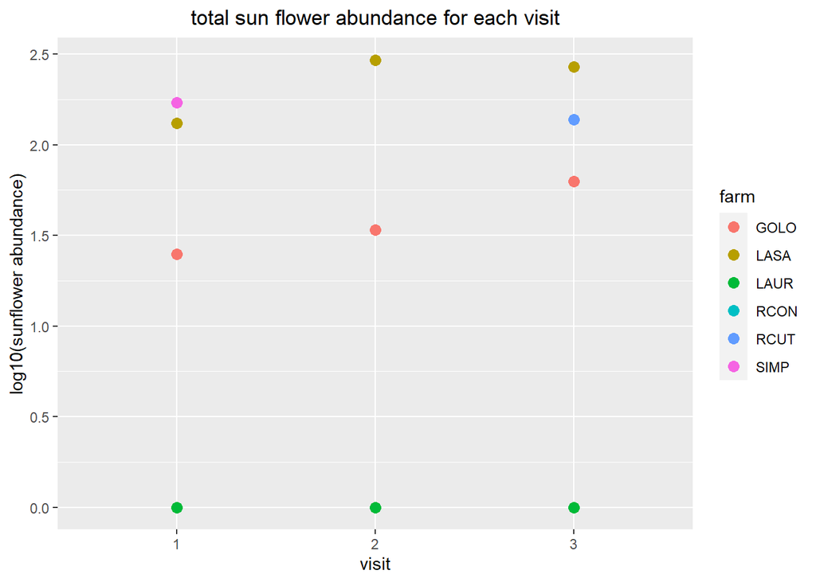

I did this to try and estimate the peak asteraceae bloom.

# DATA EXPLORATION

## 1. Check for outliers

### How do the independent variables spread?

#### flower abundance

I made these boxplots that are based o abundances from 3 farm visits. So for RCON we only measured asteraceae flowers once which were the border flowers. They are not really distributed, it is more like levels…

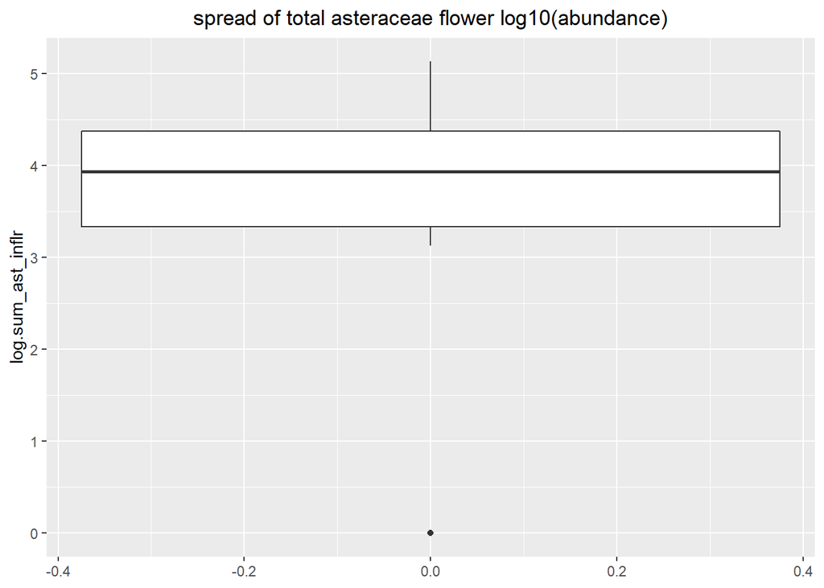

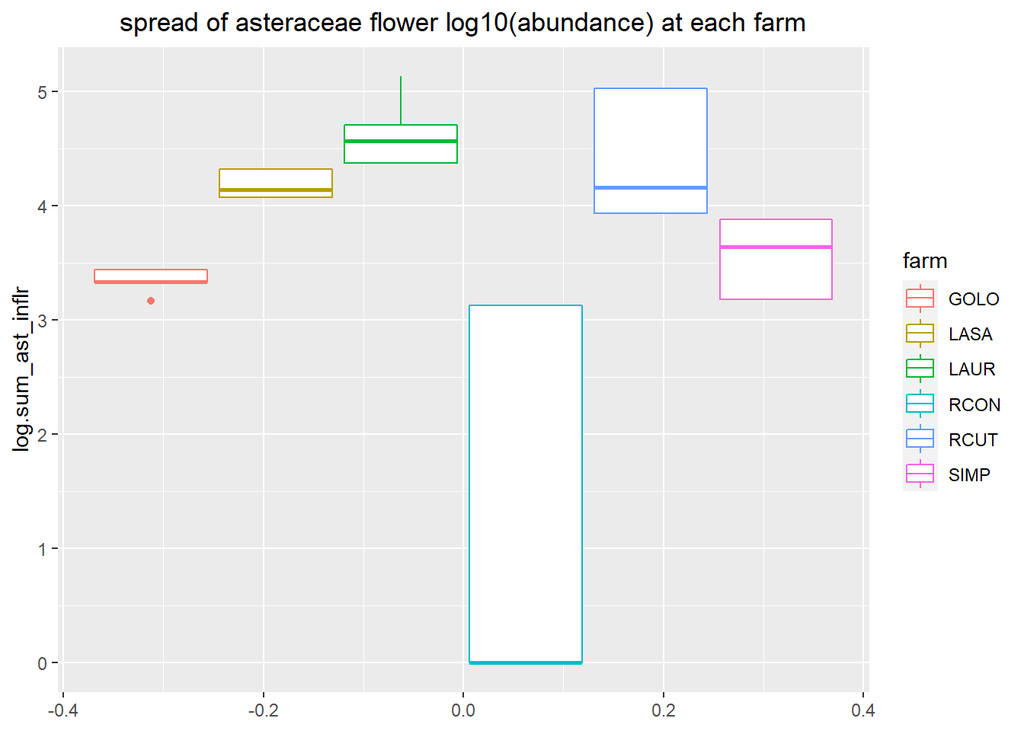

This data across farms is really just looking at totals from the three farm visits.

### covariate spread

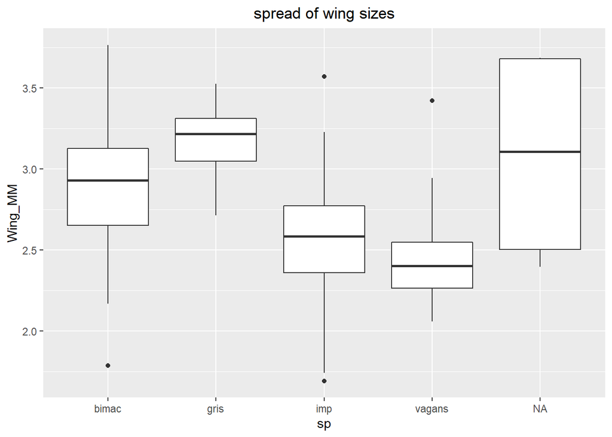

```r
wing_boxplot <- ggplot(crit_ast, aes(y = Wing_MM, x=sp)) +
  geom_boxplot()+
   ggtitle("spread of wing sizes") +
  theme(plot.title = element_text(hjust = 0.5))
wing_boxplot
```

There are 4 bees with NA for sp.

### How do the dependent variables spread?

### Crithidia levels in Bees

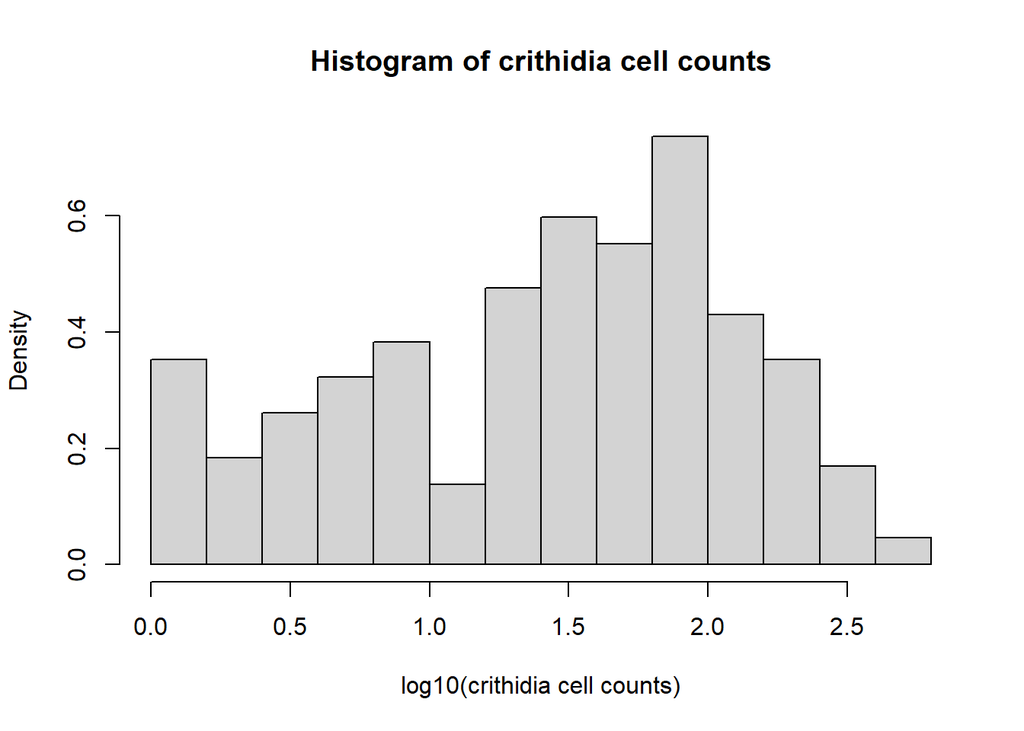

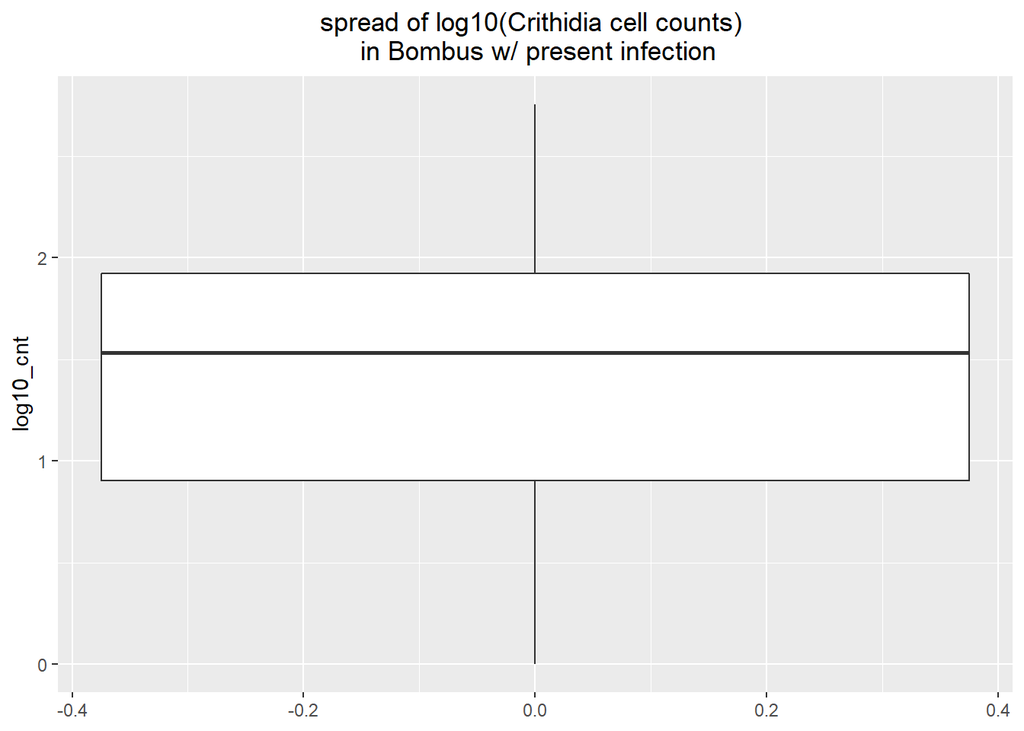

This looks slightly off from normally distributed.

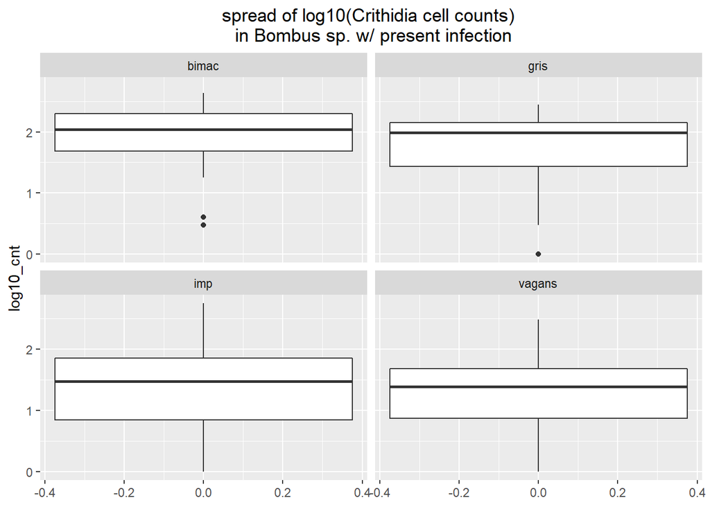

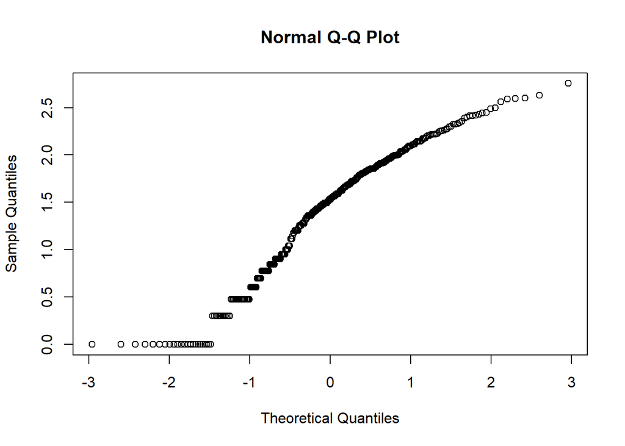

```r
qqnorm(crit_P$log10_cnt)
```

This is a qqplot of all crithidia counts in bees with present infection. The spread does not look that normal… not that it matters.

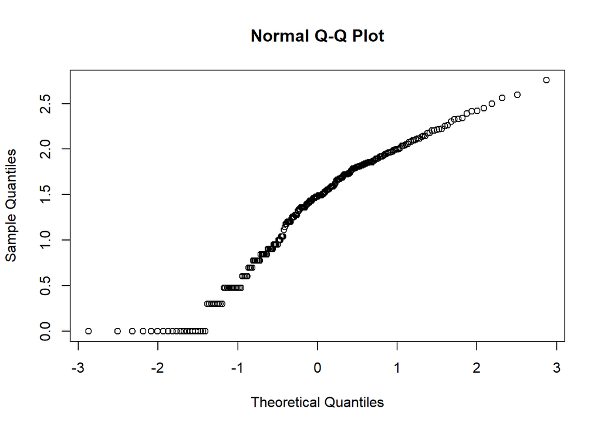

```r
crit_imp<-crit_P%>%
  filter(sp=="imp")


qqnorm(crit_imp$log10_cnt)
```

Same thing as above, just with the immpatiens data.

Doing a tester model to look for influential points. The model looks at the relationship between crithidia counts for B. impatiens that had crithidia infection and total asteraceae presence. Looking for values that may be influential… looks like there are a few above the cooks line.

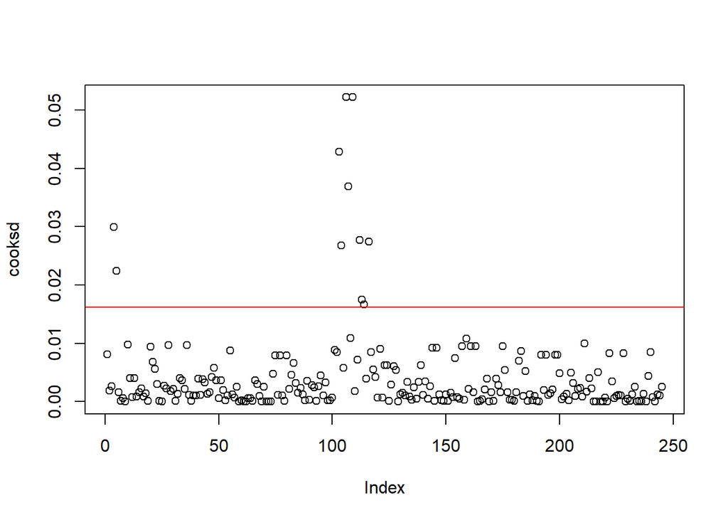

```r
mod <- lm(log10_cnt ~ log.sum_ast_inflr, data = crit_imp)
cooksd <- cooks.distance(mod)
plot(cooksd)
abline(h = 4*mean(cooksd, na.rm=T), col="red")
```

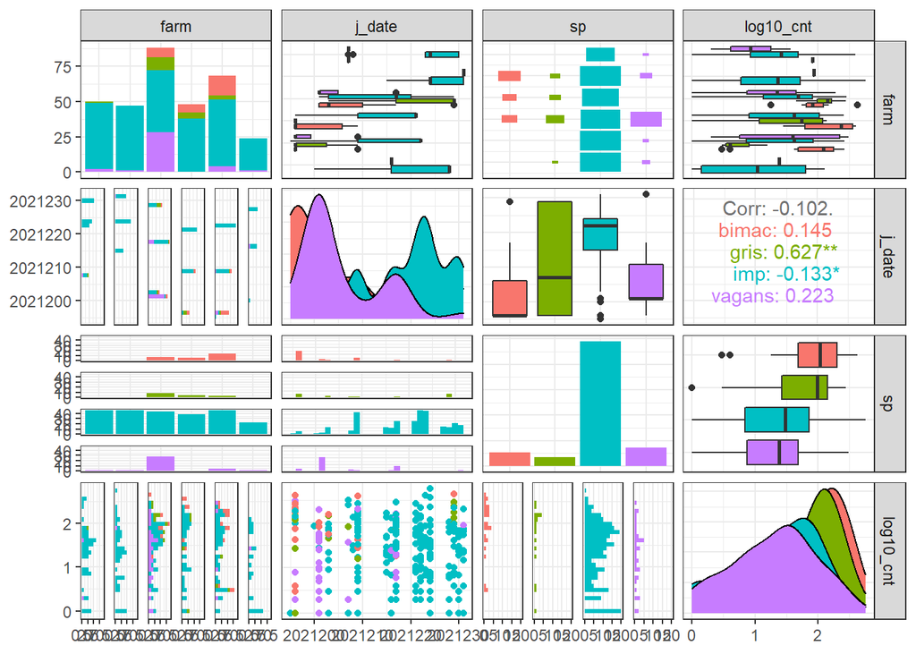

```r
ggpairs(crit_P_no_na[,c(1,4,6,9)], aes(color=sp)) + theme_bw()
```

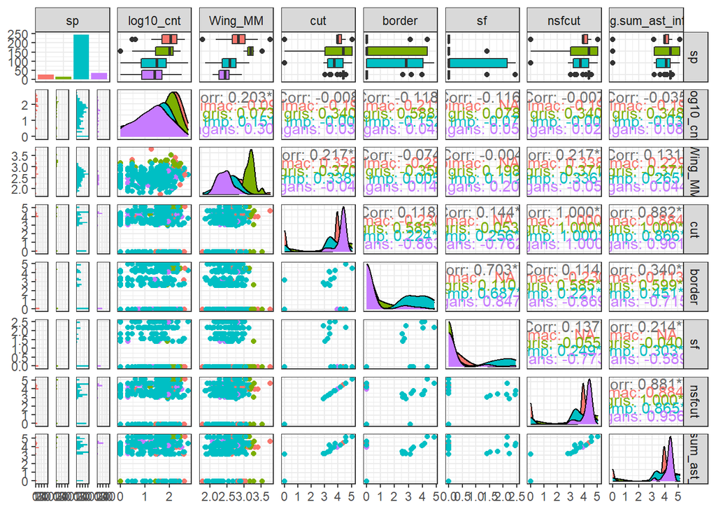

```r
ggpairs(crit_P_no_na[,c(6,9,10,11:15)], aes(color=sp)) + theme_bw()
```